# Networks, placebos and models of health regions

BIS 527: implementation notes Sections 1 and 2

2026-10-27

This builds the two neighbor networks of health regions and their weight matrices, as in `3_Implementation_Notes.pdf`, Sections 1.1 to 1.4:

- **border network:** neighbors share a boundary segment (the rook rule);
- **distance network:** neighbors’ representative points are within d* km (the notes’ rule), plus an alternative where each region is linked to its k nearest regions, so no region is left without neighbors;
- **weight matrices:** row-standardized, for the main version (border and k nearest, all 450 regions) and the notes’ version (border and d* km, on the regions that have neighbors in both);
- **placebo networks** (1.5): regions shuffled within each state;
- **models** (Section 2): M0 and M1 negative binomial models, fitted on 2014–2021, used to predict 2022, and compared with the placebos.

Inputs:

- Municipal boundaries from Christine’s pipeline (`python run_pipeline.py`, about 10-20 minutes): the `municipalities` table in `db/syphilis.duckdb`, or, if the database is not there, `data/processed/municipalities.parquet`. Both have one row per municipality with the geobr 2022 boundary as WKB in `geom_wkb`.
- `data/reference/health_regions_2023.csv` (in Git): each municipality’s 2023 health region, the pipeline’s saved copy of geobr’s file and the same mapping that `region_panel.csv` uses.
- `data/shared/region_panel.csv` (in Git): cases and births by health region and year.

Packages: `install.packages(c("sf", "spdep", "dplyr", "DBI", "duckdb", "arrow", "MASS"))` (`arrow` only for the parquet fallback).

Knit this file from the repository’s `analysis/` folder, so that the `data/` paths are found.

```r
library(sf)
library(spdep)
library(dplyr)
```

## 1. Data preparation (notes 1.1)

Read the municipalities from the database (or the pipeline’s parquet file) and rebuild each boundary from its WKB with `st_as_sfc()`. (For testing, the `boundaries` parameter can instead point to any file `sf` can read with the columns `code7` and `uf`.)

```r
read_municipalities <- function(db, boundaries = "") {
  if (nzchar(boundaries)) {
    return(st_read(boundaries, quiet = TRUE))
  }
  parquet <- "data/processed/municipalities.parquet"
  if (file.exists(db)) {
    con <- DBI::dbConnect(duckdb::duckdb(), db, read_only = TRUE)
    on.exit(DBI::dbDisconnect(con, shutdown = TRUE))
    tab <- DBI::dbGetQuery(con,
                           "SELECT code7, uf, geom_wkb FROM municipalities")
  } else if (file.exists(parquet)) {
    tab <- as.data.frame(arrow::read_parquet(
      parquet, col_select = c("code7", "uf", "geom_wkb")))
  } else {
    stop("No boundaries found: run `python run_pipeline.py` to build ", db)
  }
  geom <- st_as_sfc(structure(lapply(tab$geom_wkb, as.raw), class = "WKB"),
                    EWKB = FALSE, crs = 4674)  # SIRGAS 2000, as geobr
  st_sf(tab[c("code7", "uf")], geometry = geom)
}

munis <- read_municipalities(params$db, params$boundaries)
nrow(munis)
```

```
## [1] 5570
```

```r
mapping <- read.csv("data/reference/health_regions_2023.csv",
                    colClasses = "character") |>
  distinct(code7, health_region)
stopifnot(!anyDuplicated(mapping$code7),
          n_distinct(mapping$health_region) == 450)

munis <- munis |>
  mutate(code7 = as.character(code7)) |>
  select(code7, uf) |>
  inner_join(mapping, by = "code7")

c(municipalities = nrow(munis),
  regions = n_distinct(munis$health_region))
```

```
## municipalities        regions
##           5570            450
```

Check: every health region lies in exactly one state.

```r
states_per_region <- munis |>
  st_drop_geometry() |>
  group_by(health_region) |>
  summarise(n_states = n_distinct(uf))
stopifnot(all(states_per_region$n_states == 1))
```

Union the municipalities into region polygons, project to a metric coordinate system (Brazil Polyconic, EPSG:5880) and sort by region code to fix the node order 1, …, n.

```r
regions <- munis |>
  st_transform(5880) |>
  group_by(health_region) |>
  summarise(uf = first(uf), .groups = "drop") |>
  mutate(code_num = as.integer(health_region)) |>
  arrange(code_num) |>
  select(-code_num)

n <- nrow(regions)
n
```

```
## [1] 450
```

### Map of municipalities, health regions and states

Thin grey lines are municipalities, darker lines health regions, black lines states.

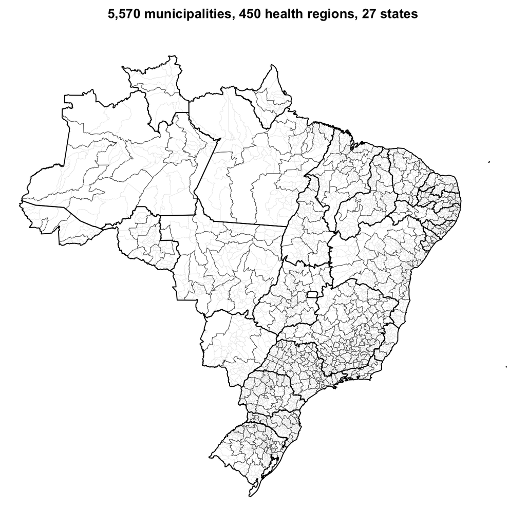

```r
# Simplified copies for drawing only (the networks use full resolution).
munis_plot <- munis |> st_transform(5880) |> st_simplify(dTolerance = 2000)
regions_plot <- st_simplify(regions, dTolerance = 2000)
states_plot <- regions |> group_by(uf) |> summarise(.groups = "drop") |>
  st_simplify(dTolerance = 2000)

par(mar = c(0, 0, 2, 0))
plot(st_geometry(munis_plot), border = "grey80", lwd = 0.2, col = "white",
     main = "5,570 municipalities, 450 health regions, 27 states")
plot(st_geometry(regions_plot), border = "grey35", lwd = 0.6, add = TRUE)
plot(st_geometry(states_plot), border = "black", lwd = 1.4, add = TRUE)
```

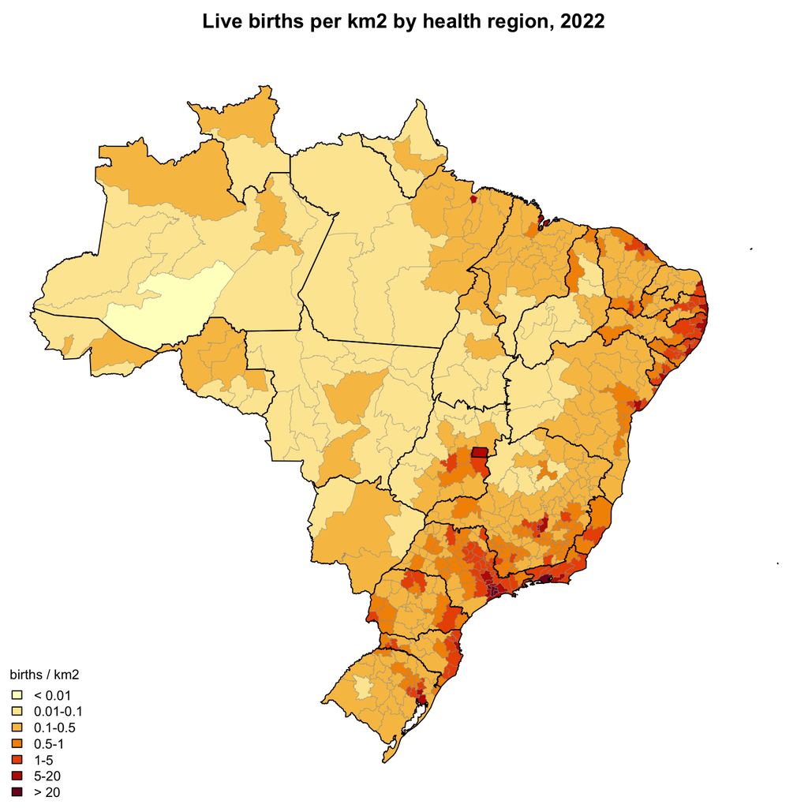

```r
# Births per km2 in each region (2022), to show how sparse the North is.
births_2022 <- read.csv("data/shared/region_panel.csv",
                        colClasses = c(health_region = "character")) |>
  filter(year == 2022) |>
  select(health_region, B)
density <- regions |>
  mutate(area_km2 = as.numeric(st_area(regions)) / 1e6) |>
  left_join(births_2022, by = "health_region") |>
  mutate(births_per_km2 = B / area_km2)

breaks <- c(0, 0.01, 0.1, 0.5, 1, 5, 20, Inf)
labels <- c("< 0.01", "0.01-0.1", "0.1-0.5", "0.5-1", "1-5", "5-20", "> 20")
classes <- cut(density$births_per_km2, breaks, labels = labels, right = FALSE)
palette <- hcl.colors(length(labels), "YlOrRd", rev = TRUE)

par(mar = c(0, 0, 2, 0))
plot(st_geometry(regions_plot), col = palette[classes], border = "grey60",
     lwd = 0.3, main = "Live births per km2 by health region, 2022")
plot(st_geometry(states_plot), border = "black", lwd = 1, add = TRUE)
legend("bottomleft", legend = labels, fill = palette, bty = "n",
       title = "births / km2", cex = 0.8)
```

```r
# How area and births line up across regions
summary_by_size <- density |>
  st_drop_geometry() |>
  mutate(size = cut(area_km2, c(0, 5e3, 2e4, 5e4, 1e5, Inf),
                    labels = c("< 5k", "5k-20k", "20k-50k", "50k-100k",
                               "> 100k"))) |>
  group_by(size) |>
  summarise(regions = n(), median_births = median(B),
            share_of_area = sum(area_km2), share_of_births = sum(B)) |>
  mutate(share_of_area = share_of_area / sum(share_of_area),
         share_of_births = share_of_births / sum(share_of_births))
knitr::kable(summary_by_size, digits = 3,
             col.names = c("Region area (km2)", "Regions", "Median births",
                           "Share of area", "Share of births"))
```

| Region area (km2) | Regions | Median births | Share of area | Share of births |
| --- | --- | --- | --- | --- |
| < 5k | 169 | 2678.0 | 0.057 | 0.461 |
| 5k-20k | 192 | 3226.0 | 0.233 | 0.342 |
| 20k-50k | 51 | 3857.0 | 0.192 | 0.089 |
| 50k-100k | 24 | 4364.0 | 0.190 | 0.056 |
| > 100k | 14 | 5938.5 | 0.327 | 0.052 |

## 2. Border network (notes 1.2)

Two regions are neighbors only if their boundaries share a segment of positive length; touching at a single point does not count. The DE-9IM pattern `****1****` says exactly that: the two boundaries meet in a line. We do not also require the interiors to be disjoint (`F***1****`): seven pairs of regions that share 130-620 km of border overlap by slivers of under 1 m² from digitizing, and the stricter pattern would drop them. It is built for the whole country at once, so neighbors across state lines are kept.

```r
rook <- st_relate(regions, regions, pattern = "****1****")

A_border <- matrix(0L, n, n, dimnames = list(regions$health_region,
                                             regions$health_region))
for (i in seq_len(n)) A_border[i, rook[[i]]] <- 1L
diag(A_border) <- 0L

m_border <- rowSums(A_border)  # number of neighbors of each region
c(links = sum(A_border) / 2, median_neighbors = median(m_border),
  min = min(m_border), max = max(m_border), isolated = sum(m_border == 0))
```

```
##            links median_neighbors              min              max
##             1248                6                1               11
##         isolated
##                0
```

Cross-check with `spdep::poly2nb(queen = FALSE)`, which uses shared boundary points instead of shared segments. The two should agree.

```r
nb_rook <- poly2nb(regions, queen = FALSE, row.names = regions$health_region)
A_spdep <- nb2mat(nb_rook, style = "B", zero.policy = TRUE)
c(pairs_differing = sum(A_spdep != A_border) / 2)
```

```
## pairs_differing
##               0
```

### Three random neighbor pairs on a map

The notes ask to check three random pairs by eye. Each map shows the pair in color and the regions around it in grey.

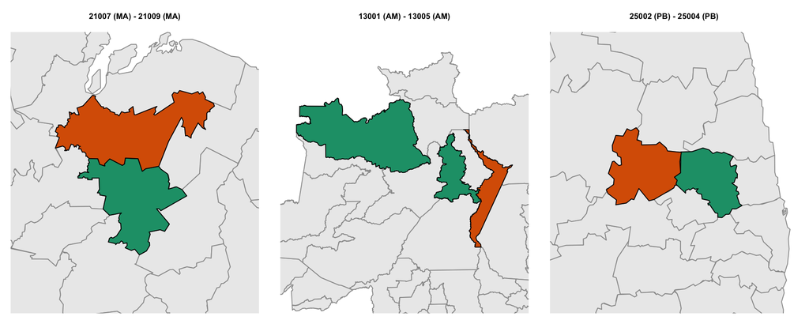

```r
set.seed(527)
border_pairs <- which(upper.tri(A_border) & A_border == 1, arr.ind = TRUE)
pick <- border_pairs[sample(nrow(border_pairs), 3), , drop = FALSE]
plot_regions <- st_simplify(regions, dTolerance = 1000)

par(mfrow = c(1, 3), mar = c(1, 1, 3, 1))
for (k in seq_len(nrow(pick))) {
  i <- pick[k, 1]; j <- pick[k, 2]
  box <- st_bbox(st_buffer(st_union(regions[c(i, j), ]), 50000))
  plot(st_geometry(plot_regions), xlim = box[c(1, 3)], ylim = box[c(2, 4)],
       col = "grey92", border = "grey60")
  plot(st_geometry(plot_regions[i, ]), col = "#1b9e77", add = TRUE)
  plot(st_geometry(plot_regions[j, ]), col = "#d95f02", add = TRUE)
  title(sprintf("%s (%s) - %s (%s)", regions$health_region[i],
                regions$uf[i], regions$health_region[j], regions$uf[j]),
        cex.main = 0.9)
}
```

## 3. Distance network (notes 1.3)

Each region gets a representative point that is guaranteed to lie inside it (`st_point_on_surface()`; a centroid can fall outside an irregular polygon). Two regions are neighbors if their points are within d km.

```r
points <- st_point_on_surface(st_geometry(regions))
D <- as.numeric(st_distance(points)) / 1000  # km, in the metric projection
D <- matrix(D, n, n, dimnames = dimnames(A_border))
```

The threshold d* is chosen from 50 to 300 km, before any model is fitted, as the d whose median number of neighbors is closest to the border network’s median; ties go to the smaller d.

```r
candidates <- c(50, 100, 150, 200, 250, 300)
target <- median(m_border)

distance_choice <- do.call(rbind, lapply(candidates, function(d) {
  A_d <- (D <= d & D > 0) * 1L
  data.frame(d_km = d, median_neighbors = median(rowSums(A_d)),
             border_median = target,
             gap = abs(median(rowSums(A_d)) - target),
             isolated = sum(rowSums(A_d) == 0))
}))
d_star <- distance_choice$d_km[order(distance_choice$gap,
                                     distance_choice$d_km)][1]
distance_choice$chosen <- distance_choice$d_km == d_star
knitr::kable(distance_choice)
```

| d_km | median_neighbors | border_median | gap | isolated | chosen |
| --- | --- | --- | --- | --- | --- |
| 50 | 0 | 6 | 6 | 321 | FALSE |
| 100 | 3 | 6 | 3 | 108 | FALSE |
| 150 | 8 | 6 | 2 | 45 | TRUE |
| 200 | 14 | 6 | 8 | 23 | FALSE |
| 250 | 21 | 6 | 15 | 15 | FALSE |
| 300 | 29 | 6 | 23 | 11 | FALSE |

```r
A_dist <- (D <= d_star & D > 0) * 1L
m_dist <- rowSums(A_dist)
c(d_star_km = d_star, links = sum(A_dist) / 2,
  median_neighbors = median(m_dist), isolated = sum(m_dist == 0))
```

```
##        d_star_km            links median_neighbors         isolated
##              150             1896                8               45
```

### Alternative: k nearest neighbors

A fixed cutoff cannot suit both the small, dense regions of the South and the huge, sparse regions of the North (see the density map): at 150 km, 45 regions have no neighbor at all. The k-nearest-neighbor network adapts the distance to each region instead: each region is linked to its k closest regions (by the same representative points). “Nearest” is not symmetric (A can be among B’s 6 nearest without B being among A’s), so a link is kept if either region is among the other’s k nearest. No region can be isolated.

k is chosen by the same rule as d*, before any model is fitted: the k from 3 to 10 whose median number of neighbors (after making links mutual) is closest to the border network’s median; ties go to the smaller k.

```r
knn_adjacency <- function(D, k) {
  K <- matrix(0L, nrow(D), ncol(D), dimnames = dimnames(D))
  for (i in seq_len(nrow(D))) {
    d_i <- D[i, ]
    d_i[i] <- Inf  # a region is not its own neighbor
    K[i, order(d_i)[seq_len(k)]] <- 1L
  }
  pmax(K, t(K))  # mutual: linked if either is among the other's k nearest
}

knn_choice <- do.call(rbind, lapply(3:10, function(k) {
  m_k <- rowSums(knn_adjacency(D, k))
  data.frame(k = k, median_neighbors = median(m_k), border_median = target,
             gap = abs(median(m_k) - target), min = min(m_k), max = max(m_k))
}))
k_star <- knn_choice$k[order(knn_choice$gap, knn_choice$k)][1]
knn_choice$chosen <- knn_choice$k == k_star
knitr::kable(knn_choice)
```

| k | median_neighbors | border_median | gap | min | max | chosen |
| --- | --- | --- | --- | --- | --- | --- |
| 3 | 4 | 6 | 2 | 3 | 7 | FALSE |
| 4 | 5 | 6 | 1 | 4 | 8 | FALSE |
| 5 | 6 | 6 | 0 | 5 | 10 | TRUE |
| 6 | 7 | 6 | 1 | 6 | 10 | FALSE |
| 7 | 8 | 6 | 2 | 7 | 12 | FALSE |
| 8 | 9 | 6 | 3 | 8 | 13 | FALSE |
| 9 | 10 | 6 | 4 | 9 | 15 | FALSE |
| 10 | 12 | 6 | 6 | 10 | 17 | FALSE |

```r
A_knn <- knn_adjacency(D, k_star)
m_knn <- rowSums(A_knn)
c(k = k_star, links = sum(A_knn) / 2, median_neighbors = median(m_knn),
  min = min(m_knn), max = max(m_knn), isolated = sum(m_knn == 0))
```

```
##                k            links median_neighbors              min
##                5             1339                6                5
##              max         isolated
##               10                0
```

How far apart k-NN neighbors are, by state (the cutoff stretches where regions are large):

```r
knn_pairs <- which(upper.tri(A_knn) & A_knn == 1, arr.ind = TRUE)
data.frame(uf = regions$uf[knn_pairs[, 1]], km = D[knn_pairs]) |>
  group_by(uf) |>
  summarise(links = n(), median_km = median(km), max_km = max(km)) |>
  arrange(desc(median_km)) |>
  knitr::kable(digits = 0)
```

| uf | links | median_km | max_km |
| --- | --- | --- | --- |
| AC | 11 | 471 | 690 |
| AM | 30 | 467 | 790 |
| MS | 8 | 349 | 489 |
| RR | 1 | 348 | 348 |
| PA | 49 | 294 | 575 |
| RO | 29 | 284 | 503 |
| MT | 40 | 263 | 428 |
| TO | 28 | 213 | 283 |
| AP | 3 | 181 | 263 |
| GO | 46 | 151 | 240 |
| PI | 33 | 148 | 273 |
| BA | 79 | 140 | 305 |
| MA | 57 | 136 | 223 |
| ES | 4 | 108 | 153 |
| PR | 66 | 108 | 209 |
| RS | 93 | 96 | 314 |
| PE | 30 | 95 | 184 |
| CE | 67 | 95 | 151 |
| SC | 50 | 86 | 161 |
| RN | 27 | 83 | 136 |
| MG | 285 | 79 | 284 |
| RJ | 18 | 77 | 133 |
| SE | 20 | 73 | 155 |
| PB | 50 | 73 | 134 |
| SP | 187 | 71 | 413 |
| AL | 28 | 63 | 162 |

Distribution of the number of neighbors in the three networks:

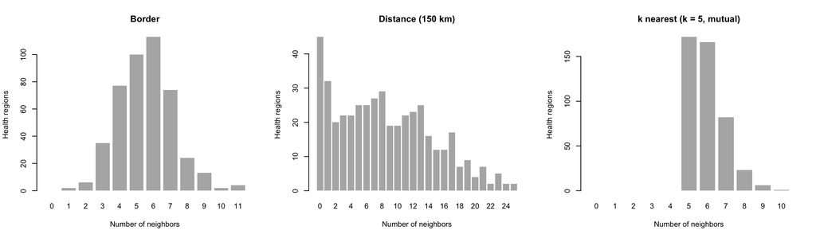

```r
par(mfrow = c(1, 3))
for (x in list(list(m_border, "Border"),
               list(m_dist, sprintf("Distance (%d km)", d_star)),
               list(m_knn, sprintf("k nearest (k = %d, mutual)", k_star)))) {
  barplot(table(factor(x[[1]], levels = 0:max(x[[1]]))), main = x[[2]],
          xlab = "Number of neighbors", ylab = "Health regions",
          col = "grey70", border = NA)
}
```

## 4. Weight matrices (notes 1.4)

Each weight matrix is the row-standardized adjacency matrix, so every row sums to one: w_ij = a_ij / m_i. Both networks in a comparison must use the same regions, and every region needs at least one neighbor in each (otherwise m_i = 0 and w_ij divides by zero).

### 4.1 Main version: border and k-NN, all 450 regions

Neither network has an isolated region, so no region is dropped.

```r
region_panel <- read.csv("data/shared/region_panel.csv",
                         colClasses = c(health_region = "character"))
stopifnot(all(m_border > 0), all(m_knn > 0))
W_border_all <- A_border / m_border
W_knn <- A_knn / m_knn
```

### 4.2 Notes’ version: border and 150 km, common regions

This follows the notes as written. Regions with no neighbors in either network are dropped, repeated until none is left (a drop can isolate another region). Every dropped region is isolated only in the distance network; all have border neighbors.

```r
keep <- seq_len(n)
dropped <- integer(0)
repeat {
  isolated <- keep[rowSums(A_border[keep, keep, drop = FALSE]) == 0 |
                   rowSums(A_dist[keep, keep, drop = FALSE]) == 0]
  if (length(isolated) == 0) break
  dropped <- c(dropped, isolated)
  keep <- setdiff(keep, isolated)
}

excluded <- data.frame(health_region = regions$health_region[dropped],
                       uf = regions$uf[dropped],
                       border_neighbors = m_border[dropped],
                       distance_neighbors = m_dist[dropped])
c(kept = length(keep), dropped = length(dropped))
```

```
##    kept dropped
##     405      45
```

```r
table(excluded$uf)
```

```
##
## AC AM AP BA GO MS MT PA RO RR RS TO
##  1  9  1  2  1  2 12  6  2  2  3  4
```

How much of the data the dropped regions hold (2014–2022):

```r
region_panel |>
  filter(year >= 2014, year <= 2022) |>
  mutate(dropped = health_region %in% excluded$health_region) |>
  group_by(dropped) |>
  summarise(regions = n_distinct(health_region), cases = sum(Y),
            births = sum(B), rate_per_1000 = 1000 * cases / births) |>
  mutate(share_cases = cases / sum(cases),
         share_births = births / sum(births)) |>
  knitr::kable(digits = 3)
```

| dropped | regions | cases | births | rate_per_1000 | share_cases | share_births |
| --- | --- | --- | --- | --- | --- | --- |
| FALSE | 405 | 198030 | 22943270 | 8.631 | 0.931 | 0.898 |
| TRUE | 45 | 14655 | 2597377 | 5.642 | 0.069 | 0.102 |

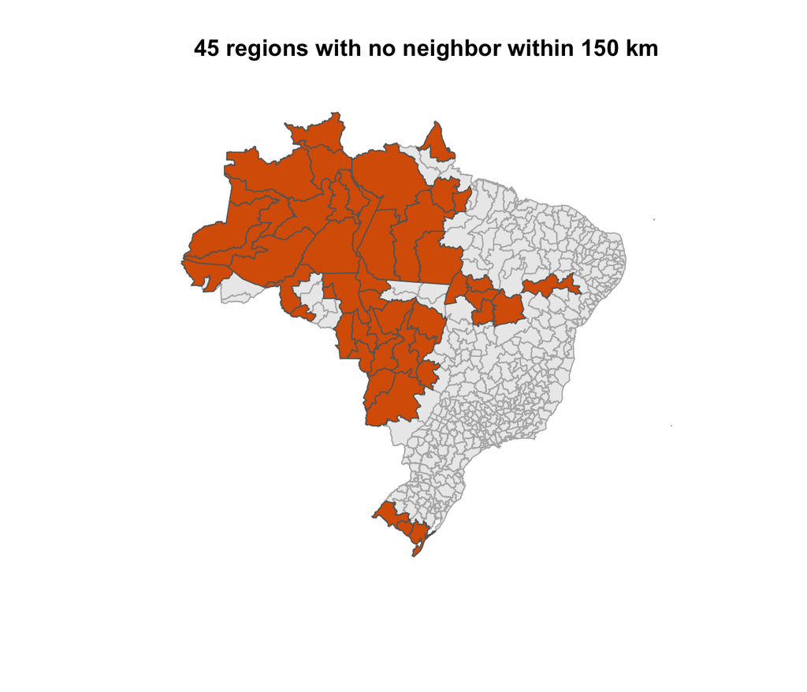

```r
plot(st_geometry(plot_regions), col = "grey92", border = "grey70",
     main = sprintf("%d regions with no neighbor within %d km",
                    length(dropped), d_star))
plot(st_geometry(plot_regions[dropped, ]), col = "#d95f02", border = "grey40",
     add = TRUE)
```

```r
A_border_c <- A_border[keep, keep]
A_dist_c <- A_dist[keep, keep]
W_border <- A_border_c / rowSums(A_border_c)
W_dist <- A_dist_c / rowSums(A_dist_c)
```

### Checks

From notes 1.4: each A is symmetric with a zero diagonal, each row of W sums to 1, and the node IDs and order match `region_panel.csv`.

```r
panel_codes <- unique(region_panel$health_region)

for (A_c in list(A_border, A_knn, A_border_c, A_dist_c)) {
  stopifnot(isSymmetric(A_c), all(diag(A_c) == 0), all(rowSums(A_c) > 0))
}
for (W in list(W_border_all, W_knn, W_border, W_dist)) {
  stopifnot(isTRUE(all.equal(unname(rowSums(W)), rep(1, nrow(W)))))
}
stopifnot(
  identical(rownames(W_border_all), rownames(W_knn)),
  identical(rownames(W_border), rownames(W_dist)),
  setequal(rownames(W_border_all), panel_codes),
  n == 450
)
"all checks pass"
```

```
## [1] "all checks pass"
```

## 5. Save

Main version (all 450 regions): `nodes.csv`, `edges_border.csv`, `edges_knn.csv`. Notes’ version (the 405 common regions): `nodes_150km.csv`, `edges_border_150km.csv`, `edges_distance_150km.csv`, `excluded_regions_150km.csv`. Edge lists have one row per neighbor pair (i < j), so any W can be rebuilt from them; `weights.rds` holds all four W matrices for R.

```r
dir.create(params$out_dir, showWarnings = FALSE, recursive = TRUE)
out <- function(x, f) write.csv(x, file.path(params$out_dir, f),
                                row.names = FALSE)
edge_list <- function(A) {
  p <- which(upper.tri(A) & A == 1, arr.ind = TRUE)
  data.frame(region_i = rownames(A)[p[, 1]], region_j = rownames(A)[p[, 2]])
}
xy <- st_coordinates(points)

nodes <- data.frame(node = seq_len(n), health_region = regions$health_region,
                    uf = regions$uf, x_m = xy[, 1], y_m = xy[, 2],
                    border_neighbors = m_border, knn_neighbors = m_knn,
                    distance_neighbors = m_dist)
out(nodes, "nodes.csv")
out(edge_list(A_border), "edges_border.csv")
out(edge_list(A_knn), "edges_knn.csv")
out(knn_choice, "knn_choice.csv")

nodes_150 <- data.frame(node = seq_along(keep),
                        health_region = regions$health_region[keep],
                        uf = regions$uf[keep],
                        border_neighbors = rowSums(A_border_c),
                        distance_neighbors = rowSums(A_dist_c))
out(nodes_150, "nodes_150km.csv")
out(edge_list(A_border_c), "edges_border_150km.csv")
out(edge_list(A_dist_c), "edges_distance_150km.csv")
out(excluded, "excluded_regions_150km.csv")
out(distance_choice, "distance_choice.csv")

saveRDS(list(main = list(W_border = W_border_all, W_knn = W_knn,
                         k = k_star),
             notes_150km = list(W_border = W_border, W_dist = W_dist,
                                d_star = d_star)),
        file.path(params$out_dir, "weights.rds"))

c(nodes = n, border_edges = sum(A_border) / 2, knn_edges = sum(A_knn) / 2,
  nodes_150km = length(keep))
```

```
##        nodes border_edges    knn_edges  nodes_150km
##          450         1248         1339          405
```

## 6. Placebo networks (notes 1.5)

A placebo shuffles the regions within each state and applies the same shuffle to the rows and columns of A: A_p[i, j] = A[perm[i], perm[j]]. The rows and columns keep their original region codes, so when the data are matched by code, each region gets the neighbors of the region it was swapped with. Each region keeps its number of neighbors, and the case data stay fixed.

```r
make_placebo <- function(A, uf, seed) {
  set.seed(seed)
  perm <- seq_along(uf)
  for (s in unique(uf)) {
    idx <- which(uf == s)
    perm[idx] <- idx[sample.int(length(idx))]  # sample(idx) fails if length 1
  }
  A_p <- A[perm, perm]
  dimnames(A_p) <- dimnames(A)  # keep the original labels
  A_p
}

changed_share <- function(A_p, A) sum(A_p == 1 & A == 0) / sum(A == 1)
```

The toy test from the notes: six nodes with links A–B, B–C, B–D, C–D, D–E and E–F; A to D in state 1, E and F in state 2. After swapping A and D, A’s neighbors should be B, C and E, and D’s only neighbor should be B.

```r
toy <- matrix(0, 6, 6, dimnames = list(LETTERS[1:6], LETTERS[1:6]))
for (e in list(c("A", "B"), c("B", "C"), c("B", "D"), c("C", "D"),
               c("D", "E"), c("E", "F"))) {
  toy[e[1], e[2]] <- toy[e[2], e[1]] <- 1
}
perm <- c(4, 2, 3, 1, 5, 6)  # swap A and D only
toy_p <- toy[perm, perm]
dimnames(toy_p) <- dimnames(toy)
stopifnot(identical(names(which(toy_p["A", ] == 1)), c("B", "C", "E")),
          identical(names(which(toy_p["D", ] == 1)), "B"))
"toy test passes"
```

```
## [1] "toy test passes"
```

The main version gets 19 placebos of each network (border and k-NN) on all 450 regions. The notes only ask for border placebos; the k-NN placebos give the k-NN model its own null. The 150 km comparison uses border and 150 km placebos on its 405 regions. Every placebo is checked to be symmetric with a zero diagonal and the same neighbor counts as the real network.

```r
seeds <- seq_len(params$n_placebos)
uf_all <- regions$uf
uf_c <- regions$uf[keep]

make_placebos <- function(A, uf) {
  lapply(seeds, function(s) {
    A_p <- make_placebo(A, uf, s)
    stopifnot(isSymmetric(A_p), all(diag(A_p) == 0),
              identical(unname(sort(rowSums(A_p))), unname(sort(rowSums(A)))))
    A_p
  })
}
placebos <- list(border = make_placebos(A_border, uf_all),
                 knn = make_placebos(A_knn, uf_all),
                 border_150km = make_placebos(A_border_c, uf_c),
                 distance_150km = make_placebos(A_dist_c, uf_c))
real <- list(border = A_border, knn = A_knn,
             border_150km = A_border_c, distance_150km = A_dist_c)

sapply(names(placebos), function(nm) {
  s <- sapply(placebos[[nm]], changed_share, A = real[[nm]])
  c(min = min(s), median = median(s), max = max(s))
}) |> knitr::kable(digits = 2, caption = "Share of real links changed")
```

Share of real links changed

|  | border | knn | border_150km | distance_150km |
| --- | --- | --- | --- | --- |
| min | 0.83 | 0.81 | 0.84 | 0.78 |
| median | 0.85 | 0.82 | 0.85 | 0.79 |
| max | 0.86 | 0.84 | 0.87 | 0.81 |

## 7. Models M0 and M1 (notes Section 2)

For each region and year, x = log(1 + 1000 Y / B). The models are

- M0: Y ~ own_lag + state + trend, offset log B;
- M1: Y ~ own_lag + Z + state + trend, offset log B,

where own_lag = x in the previous year, Z is the neighbors’ average of own_lag (from W), standardized with the 2014–2021 mean and SD, and trend = year − 2014. Both are negative binomial (`MASS::glm.nb`), fitted on 2014–2021 and used to predict 2022.

The score is not set by the notes; we use the birth-weighted RMSE of the 2022 rate per 1,000 births (lower is better). T = score(M0) − score(M1), so T > 0 means the neighbors improve the 2022 prediction.

```r
region_panel <- region_panel |> mutate(x = log1p(1000 * Y / B))
years <- sort(unique(region_panel$year))

# own_lag, Z and trend for the regions in W, in W's order (notes 2.1).
model_data <- function(W) {
  codes <- rownames(W)
  p <- region_panel |> filter(health_region %in% codes)
  i <- match(p$health_region, codes)
  j <- match(p$year, years)
  x <- matrix(NA_real_, length(codes), length(years))
  x[cbind(i, j)] <- p$x
  lag <- cbind(NA, x[, -length(years)])  # x_{i,t-1}; years are consecutive
  nbr <- W %*% lag
  d <- p |>
    mutate(own_lag = lag[cbind(i, j)], nbr = nbr[cbind(i, j)],
           trend = year - 2014) |>
    filter(year >= 2014, year <= 2022)
  train <- d$year <= 2021
  d$Z <- (d$nbr - mean(d$nbr[train])) / sd(d$nbr[train])
  d
}

birth_weighted_rmse <- function(Y, B, pred) {
  sqrt(sum(B * (1000 * pred / B - 1000 * Y / B)^2) / sum(B))
}

# Fit on 2014-2021, predict 2022 (notes 2.2).
fit_predict <- function(W, with_z) {
  d <- model_data(W)
  f <- if (with_z) {
    Y ~ own_lag + Z + uf + trend + offset(log(B))
  } else {
    Y ~ own_lag + uf + trend + offset(log(B))
  }
  train <- d[d$year <= 2021, ]
  test <- d[d$year == 2022, ]
  fit <- MASS::glm.nb(f, data = train)
  pred <- unname(predict(fit, newdata = test, type = "response"))
  stopifnot(all(is.finite(pred)), all(pred >= 0))
  diag <- data.frame(regions = nrow(test), converged = fit$converged,
                     theta = fit$theta, theta_se = fit$SE.theta,
                     aic = AIC(fit),
                     score_2022 = birth_weighted_rmse(test$Y, test$B, pred))
  if (with_z) {
    co <- summary(fit)$coefficients["Z", ]
    diag <- cbind(diag, gamma = co[["Estimate"]], gamma_se = co[["Std. Error"]],
                  rate_ratio = exp(co[["Estimate"]]),
                  rr_low = exp(co[["Estimate"]] - 1.96 * co[["Std. Error"]]),
                  rr_high = exp(co[["Estimate"]] + 1.96 * co[["Std. Error"]]),
                  wald_p = co[["Pr(>|z|)"]])
  }
  list(fit = fit, diag = diag,
       pred = test[c("health_region", "uf", "Y", "B")] |> mutate(pred = pred))
}

# One-sided rank p: (1 + #{placebo >= real}) / (1 + number of placebos).
rank_p <- function(real, null) (1 + sum(null >= real)) / (1 + length(null))
```

### Real networks

The main version uses the 450 regions; the 150 km comparison refits M0 on its 405 regions, so each M1 is compared with an M0 on the same regions. (M0 does not use W; any W with the right regions works.)

```r
fits <- list(
  "M0" = fit_predict(W_border_all, FALSE),
  "M1 border" = fit_predict(W_border_all, TRUE),
  "M1 k-NN" = fit_predict(W_knn, TRUE),
  "M0 (150 km regions)" = fit_predict(W_border, FALSE),
  "M1 border (150 km regions)" = fit_predict(W_border, TRUE),
  "M1 150 km" = fit_predict(W_dist, TRUE))
stopifnot(all(sapply(fits, function(f) f$diag$converged)))

m0_score <- c(main = fits[["M0"]]$diag$score_2022,
              comparison = fits[["M0 (150 km regions)"]]$diag$score_2022)
```

### Placebo networks

Each placebo W is used in place of the real W; Z is standardized with the placebo’s own training data.

```r
placebo_null <- function(nm, m0) {
  do.call(rbind, lapply(seq_along(seeds), function(k) {
    A_p <- placebos[[nm]][[k]]
    d <- fit_predict(A_p / rowSums(A_p), TRUE)$diag
    data.frame(network = nm, seed = seeds[k],
               changed_share = changed_share(A_p, real[[nm]]),
               converged = d$converged, score_2022 = d$score_2022,
               T = m0 - d$score_2022, gamma = d$gamma)
  }))
}
null <- rbind(placebo_null("border", m0_score[["main"]]),
              placebo_null("knn", m0_score[["main"]]),
              placebo_null("border_150km", m0_score[["comparison"]]),
              placebo_null("distance_150km", m0_score[["comparison"]]))
table(null$network, null$converged)
```

```
##
##                  TRUE
##   border           19
##   border_150km     19
##   distance_150km   19
##   knn              19
```

### Results

```r
placebo_of <- c("M1 border" = "border", "M1 k-NN" = "knn",
                "M1 border (150 km regions)" = "border_150km",
                "M1 150 km" = "distance_150km")
results <- do.call(rbind, lapply(names(fits), function(nm) {
  d <- fits[[nm]]$diag
  m0 <- if (grepl("150 km", nm)) m0_score[["comparison"]] else m0_score[["main"]]
  row <- data.frame(model = nm, version = if (grepl("150 km", nm))
                      "comparison (405)" else "main (450)",
                    d[c("regions", "converged", "theta", "aic", "score_2022")],
                    T = m0 - d$score_2022, gamma = NA, rate_ratio = NA,
                    rr_low = NA, rr_high = NA, wald_p = NA,
                    T_rank_p = NA, gamma_rank_p = NA)
  if (nm %in% names(placebo_of)) {
    nl <- null[null$network == placebo_of[[nm]], ]
    row[c("gamma", "rate_ratio", "rr_low", "rr_high", "wald_p")] <-
      d[c("gamma", "rate_ratio", "rr_low", "rr_high", "wald_p")]
    row$T_rank_p <- rank_p(row$T, nl$T)
    row$gamma_rank_p <- rank_p(row$gamma, nl$gamma)
  }
  row
}))

results |>
  transmute(model, regions, theta, score_2022, T,
            `rate ratio (95% CI)` = ifelse(is.na(rate_ratio), "",
              sprintf("%.3f (%.3f–%.3f)", rate_ratio, rr_low, rr_high)),
            wald_p, T_rank_p, gamma_rank_p) |>
  knitr::kable(digits = 3, caption = sprintf(
    "M0 and M1, trained 2014–2021, scored on 2022 (%d placebos per network)",
    length(seeds)))
```

M0 and M1, trained 2014–2021, scored on 2022 (19 placebos per network)

| model | regions | theta | score_2022 | T | rate ratio (95% CI) | wald_p | T_rank_p | gamma_rank_p |
| --- | --- | --- | --- | --- | --- | --- | --- | --- |
| M0 | 450 | 5.919 | 3.302 | 0.000 |  | NA | NA | NA |
| M1 border | 450 | 5.922 | 3.298 | 0.004 | 1.040 (1.016–1.065) | 0.001 | 0.65 | 0.05 |
| M1 k-NN | 450 | 5.917 | 3.330 | -0.029 | 1.041 (1.016–1.066) | 0.001 | 0.80 | 0.05 |
| M0 (150 km regions) | 405 | 5.910 | 3.450 | 0.000 |  | NA | NA | NA |
| M1 border (150 km regions) | 405 | 5.915 | 3.456 | -0.006 | 1.043 (1.018–1.069) | 0.001 | 0.70 | 0.05 |
| M1 150 km | 405 | 5.909 | 3.510 | -0.060 | 1.029 (1.005–1.053) | 0.019 | 0.95 | 0.05 |

How to read it:

- **rate ratio:** exp(γ). Holding the region’s own lagged rate, state and trend fixed, a 1 SD higher lagged neighbor average multiplies the expected rate by this much.
- **T:** the gain in 2022 prediction over M0 (birth-weighted RMSE per 1,000 births). T > 0 means the neighbors help.
- **T rank p / gamma rank p:** where the real network falls among its placebos. With 19 placebos the smallest possible value is 0.05, so these are descriptive, not a significance test (notes 2.3).
- A better prediction shows that nearby regions carry useful information. It does not show that syphilis spreads between regions (notes 2.3).

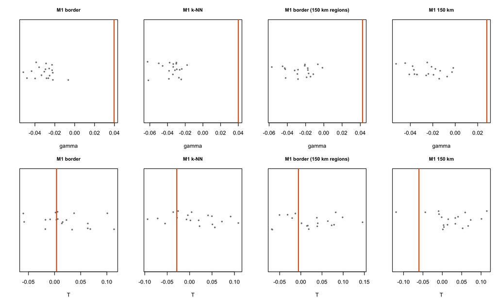

```r
op <- par(mfrow = c(2, 4), mar = c(4, 3, 3, 1))
for (stat in c("gamma", "T")) {
  for (nm in names(placebo_of)) {
    nl <- null[null$network == placebo_of[[nm]], stat]
    r <- results[results$model == nm, stat]
    stripchart(nl, method = "jitter", pch = 16, col = "grey50",
               xlim = range(c(nl, r)), main = nm, xlab = stat, cex.main = 0.9)
    abline(v = r, col = "#d95f02", lwd = 2)
  }
}
```

```r
par(op)
```

Grey points are the placebos; the orange line is the real network.

### Save results

```r
dir.create(params$results_dir, showWarnings = FALSE, recursive = TRUE)
out_r <- function(x, f) write.csv(x, file.path(params$results_dir, f),
                                  row.names = FALSE)
out_r(results, "model_comparison.csv")
out_r(null, "placebo_scores.csv")
out_r(do.call(rbind, lapply(names(fits), function(nm)
  fits[[nm]]$pred |> mutate(model = nm))), "predictions_2022.csv")
out_r(do.call(rbind, lapply(names(fits), function(nm) {
  co <- summary(fits[[nm]]$fit)$coefficients
  data.frame(model = nm, term = rownames(co), estimate = co[, 1],
             se = co[, 2], row.names = NULL)
})), "coefficients.csv")
list.files(params$results_dir)
```

```
## [1] "coefficients.csv"     "model_comparison.csv" "placebo_scores.csv"
## [4] "predictions_2022.csv" "simulation_check.csv"
```